# Stablecoins

2026-10-31

Desideriamo effettuare un breve confronto sui trasferimenti di USDT, USDC e DAI sulla blockchain Ethereum.

## Scaricamento dei dati

```r
library(httr2)
library(tidyverse)
library(lubridate)
```

```r
api_key <- Sys.getenv("ETHERSCAN_API_KEY")

get_block <- function(date, closest = "before") {

  response <- request(
    "https://api.etherscan.io/v2/api"
  ) |>
    req_url_query(
      chainid = 1,
      module = "block",
      action = "getblocknobytime",
      timestamp = as.integer(
        as.numeric(as.POSIXct(date, tz = "UTC"))
      ),
      closest = closest,
      apikey = api_key
    ) |>
    req_perform()

  result <- resp_body_json(response)

  if (result$status != "1") {
    stop(result$result)
  }

  as.numeric(result$result)
}
```

Scelgo un periodo da considerare

```r
start_date <- "2026-09-01 00:00:00"
end_date   <- "2026-10-01 00:00:00"

start_block <- get_block(start_date, "after")
end_block <- get_block(end_date, "before")
```

Definisco la funzione per scaricare i dati.

```r
download_transfers <- function(
    contract,
    token,
    start_block,
    end_block
) {

  all_data <- list()

  # Divido in blocchi piu' piccoli
  chunk_size <- 50000

  block_starts <- seq(
    start_block,
    end_block,
    by = chunk_size
  )

  for (i in seq_along(block_starts)) {

    from_block <- block_starts[i]

    to_block <- min(
      from_block + chunk_size - 1,
      end_block
    )

    page <- 1

    repeat {

      response <- request(
        "https://api.etherscan.io/v2/api"
      ) |>
        req_url_query(
          chainid = 1,
          module = "account",
          action = "tokentx",
          contractaddress = contract,
          startblock = from_block,
          endblock = to_block,
          page = page,
          offset = 10000,
          sort = "asc",
          apikey = api_key
        ) |>
        req_perform()

      result <- resp_body_json(response)

      if (result$status == "0") {

        if (grepl(
          "no transactions found",
          result$result,
          ignore.case = TRUE
        )) {
          break
        }

        stop(result$result)
      }

      transfers <- map_dfr(
        result$result,
        as_tibble
      )

      all_data[[length(all_data) + 1]] <-
        transfers

      message(
        token,
        " | Block range: ",
        from_block,
        " - ",
        to_block,
        " | Page: ",
        page
      )

      if (nrow(transfers) < 10000) {
        break
      }

      page <- page + 1

      Sys.sleep(0.25)
    }

    Sys.sleep(0.25)
  }

  bind_rows(all_data) |>
    mutate(token = token)
}
```

Scarico i dati di mio interesse:

```r
usdc <- download_transfers(
  contract = "0xa0b86991c6218b36c1d19d4a2e9eb0ce3606eb48",
  token = "USDC",
  start_block = start_block,
  end_block = end_block
) |>
  select(timeStamp, value, tokenName, tokenDecimal)
usdc
```

```r
usdt <- download_transfers(
  contract = "0xdac17f958d2ee523a2206206994597c13d831ec7",
  token = "USDT",
  start_block = start_block,
  end_block = end_block
) |>
  select(timeStamp, value, tokenName, tokenDecimal)
usdt
```

```r
dai <- download_transfers(
  contract = "0x6b175474e89094c44da98b954eedeac495271d0f",
  token = "DAI",
  start_block = start_block,
  end_block = end_block
) |>
  select(timeStamp, value, tokenName, tokenDecimal)
dai
```

Uniamo i tre dataset in un unico dataset e salviamolo in csv:

```r
df <- bind_rows(usdc, usdt, dai)
write_csv(df, "stablecoins.csv")
```

```r
df <- read_csv("stablecoins.csv")
df
```

```
## # A tibble: 15,000 × 4
##     timeStamp      value tokenName tokenDecimal
##         <dbl>      <dbl> <chr>            <dbl>
##  1 1788220811 7332300096 USDC                 6
##  2 1788220811 7332300096 USDC                 6
##  3 1788220811 1529239213 USDC                 6
##  4 1788220811 1529239184 USDC                 6
##  5 1788220811  202869504 USDC                 6
##  6 1788220811  166814098 USDC                 6
##  7 1788220811    1232748 USDC                 6
##  8 1788220811   23426501 USDC                 6
##  9 1788220811     209603 USDC                 6
## 10 1788220811   24449646 USDC                 6
## # ℹ 14,990 more rows
```

## Tidy del dataset

Calcoliamo il valore in dollari di ogni transazione:

```r
df1 <- df |>
  mutate(true_value = value / (10 ^ tokenDecimal)) |>
  select(-value, -tokenDecimal) |>
  mutate(tokenName = recode(tokenName,
                            "Tether USD" = "USDT",
                            "Dai Stablecoin" = "DAI")) |>
  rename(ts = timeStamp, valuta = tokenName, importo = true_value) |>
  mutate(valuta = factor(valuta))
df1
```

```
## # A tibble: 15,000 × 3
##            ts valuta  importo
##         <dbl> <fct>     <dbl>
##  1 1788220811 USDC   7332.
##  2 1788220811 USDC   7332.
##  3 1788220811 USDC   1529.
##  4 1788220811 USDC   1529.
##  5 1788220811 USDC    203.
##  6 1788220811 USDC    167.
##  7 1788220811 USDC      1.23
##  8 1788220811 USDC     23.4
##  9 1788220811 USDC      0.210
## 10 1788220811 USDC     24.4
## # ℹ 14,990 more rows
```

## Differenze tra le dimensioni delle transizioni nelle diverse valute

Ora che abbiamo il dataset ordinato possiamo analizzare le distribuzioni degli importi al variare della valuta.

```r
df1 |> group_by(valuta) |>
  summarise(median(importo), mean(importo))
```

```
## # A tibble: 3 × 3
##   valuta `median(importo)` `mean(importo)`
##   <fct>              <dbl>           <dbl>
## 1 DAI                173.         1111135.
## 2 USDC                62.3          23876.
## 3 USDT                52.2           5878.
```

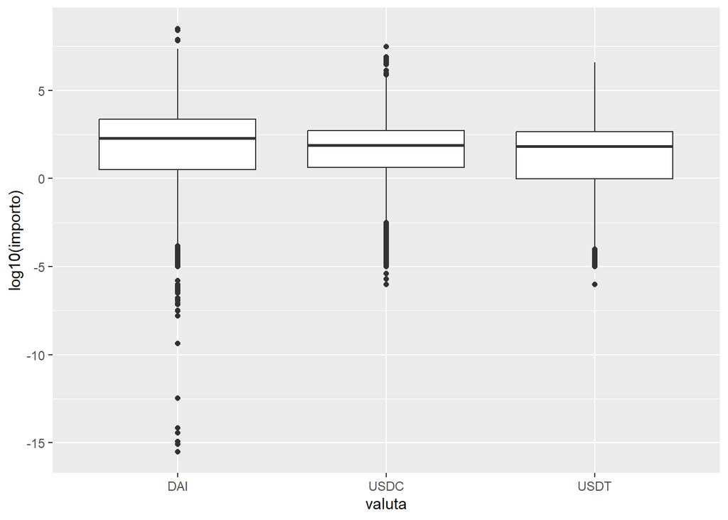

```r
ggplot(data = df1, mapping = aes(x = valuta, y = log10(importo))) +
  geom_boxplot()
```

Dal grafico e dai valori di media e mediana calcolati sopra emerge che USDC e USDT sono usati per effettuare trasferimenti di importi analoghi, pressoché con la stessa distribuzione. Il DAI viene usato per trasferire importi con una variabilità molto più ampia (da cifre infime a molto consistenti) e presenta una mediana pari circa al triplo delle altre due valute.

## Analisi dei volumi trasferiti

```r
df1 |> group_by(valuta) |>
  summarise(volume_milioni = sum(importo) / 1000000)
```

```
## # A tibble: 3 × 2
##   valuta volume_milioni
##   <fct>           <dbl>
## 1 DAI            5556.
## 2 USDC            119.
## 3 USDT             29.4
```

Gli importi trasferiti nelle tre stablecoins nel mese di settembre 2026 sono molto differenti:

I grandi trasferimenti fatti in DAI si fanno sentire e portano il DAI ad avere un volume trasferito di circa 5.5 miliardi di dollari.

Per quanto riguarda le altre due valute, sebbene gli importi siano quasi equidistibuiti, il USDC ha un volume pari al quadruplo degli USDT. Probabilmente perché più utilizzato.